# Aplicação do algoritmo PSF a séries de vazão naturalizada

Jerônimo Acker D’Ornellas

05/05/2021

## Objetivo

O objetivo do testePSF é realizar a aplicação do algoritmo PSF em séries hidrológicas e comparar o desempenho do algoritmo com outros métodos univariados amplamente usados para os dados da bacia hidrográfica do posto ONS de código 74.

## Pré-requisitos

Pacotes necessários:

```r
if(!require(PSF)) install.packages("PSF")
if(!require(timetk)) remotes::install_github("business-science/timetk")
# tive que usar o tidyr do github
# por causa de erro no unnest()
#  Error: Input must be list of vectors
# remotes::install_github("tidyverse/tidyr")
pacotes <- c(
  "here",
  "usethis",
  "data.table",
  "HEobs",
  "PSF",
  "tidyverse",
  "lubridate",
  "fs",
  "checkmate",
  "xts",
  "hydroGOF",
  "ModelMetrics",
  "forecast",
  "timetk"
)
# Carregar os pacotes
easypackages::libraries(pacotes)
```

Scripts:

```r
source(here('R', 'load-data.R'))
source(here('R', 'utils.R'))
```

### Dados de vazão

Os dados importados de vazão devem ser regularmente espaçados no tempo. Esta adequação das séries diárias, se necessária, pode ser realizada com a função `complete_dates()` do pacote **`{lhmetools}`**. Assim assegura-se que todas estações possuam 1 observação por dia e sem datas faltantes.

```r
qnat_data <- qnat_dly_ons() %>%
  select(date, qnat, code_stn) %>%
  lhmetools::complete_dates(group = "code_stn")
glimpse(qnat_data)
```

```
#> Rows: 2,796,267
#> Columns: 3
#> $ date     <date> 1931-01-02, 1931-01-03, 1931-01-04, 1931-01-05, 1931-01-06, ~
#> $ code_stn <dbl> 1, 1, 1, 1, 1, 1, 1, 1, 1, 1, 1, 1, 1, 1, 1, 1, 1, 1, 1, 1, 1~
#> $ qnat     <dbl> NA, NA, NA, NA, NA, NA, NA, NA, NA, NA, NA, NA, NA, NA, NA, N~
```

Os dados importados precisam filtrados para o posto de interesse: posto 74 da ONS (G. B. Munhoz).

```r
qnat_posto <- qnat_data %>%
  sel_station(.,station = 74)
glimpse(qnat_posto)
```

```
#> Rows: 32,141
#> Columns: 3
#> $ date     <date> 1931-01-02, 1931-01-03, 1931-01-04, 1931-01-05, 1931-01-06, ~
#> $ code_stn <dbl> 74, 74, 74, 74, 74, 74, 74, 74, 74, 74, 74, 74, 74, 74, 74, 7~
#> $ qnat     <dbl> NA, NA, NA, NA, NA, NA, NA, NA, NA, NA, NA, NA, NA, NA, NA, N~
```

Observam-se dados faltantes na série do posto 74, então selecionaremos somente os meses com pelo menos 28 observações válidas e anos completos.

```r
qnat_posto_mly <- qnat_posto %>%
  apply_cmonth(.,ndays_thresh = 28)

# check
#str(qnat_posto_mly)
# qnat_posto_mly %>%
#   lhmetools::complete_dates(group = "code_stn", time_step = # "month") %>%
#   str()
```

Para robustez da avaliação consideraremos apenas anos que atendam ao critério de disponibilidade nos 12 meses do ano e verificamos se a série é múltipla de 12 como requisito da aplicação do PSF.

```r
# anos completos
anos_comp <- get_cyears(qnat_posto_mly)

# filtra observações com os anos completos
qnat_posto_mly <- qnat_posto_mly %>%
  apply_cyears() %>%
  select(date,qnat_obs)

# check
head(qnat_posto_mly)
```

```
#> # A tibble: 6 x 2
#>   date       qnat_obs
#>   <date>        <dbl>
#> 1 1969-01-01     459.
#> 2 1969-02-01     541.
#> 3 1969-03-01     565.
#> 4 1969-04-01    1207.
#> 5 1969-05-01     686.
#> 6 1969-06-01    1334.
```

```r
tail(qnat_posto_mly)
```

```
#> # A tibble: 6 x 2
#>   date       qnat_obs
#>   <date>        <dbl>
#> 1 2018-07-01     238.
#> 2 2018-08-01     175.
#> 3 2018-09-01     475.
#> 4 2018-10-01    1468.
#> 5 2018-11-01     631.
#> 6 2018-12-01     280.
```

```r
stopifnot(nrow(qnat_posto_mly) %% 12 == 0)
#nrow(qnat_posto_mly) %/% 12
```

### Aplicação do algoritmo PSF

O PSF é uma técnica de previsão para séries temporais univariadas e sua premissa é de que há um padrão de sequência na série analisada. O algoritmo [apresentou](https://journal.r-project.org/archive/2017/RJ-2017-021/RJ-2017-021.pdf) um desempenho superior, baseado na métrica RMSE, a modelos de séries temporais mais usados (autoregressivos e de suavização exponencial). Além disso, essa técnica possui o diferencial de usar as próprias previsões para retroalimentar a previsão para horizontes maiores. Iremos verificar o seu desempenho para a série hidrológica do posto 74 da ONS (G. B. Munhoz). As observações do período de 1969-2016 serão usadas para treinamento do modelo, enquanto que os dois últimos anos (2017 e 2018) serão usados para avaliar seu desempenho.

```r
# dados de treinamento (sem últimos dois anos)
train_posto_qmly <- qnat_posto_mly  %>%
  get_traindt()
# dados de teste: 2017 e 2018
(leave_out <- tail(anos_comp, n = 2))
```

```
#> [1] 2017 2018
```

O treinamento do modelo no pacote `PSF` é feito através da função `psf` que requer como entrada uma série temporal univariada em um formato numérico. Além disso, é possível especificar os parâmetros: `k`,`w` e `cycle`. O parâmetro `cycle` corresponde ao número de valores de um ciclo na série temporal e deve ser adicionado caso os dados não estejam no formato `ts` (série temporal).

```r
# Os dados não estão no formato ts (série temporal)
(is.ts(train_posto_qmly))
```

```
#> [1] FALSE
```

A técnica `PSF` pode ser descrita em duas etapas: agrupamento e previsão. Na primeira etapa o método de clustering k-means é aplicado com o intuito de agrupar e rotular as observações do conjunto de dados. Na previsão o padrão de sequência anterior ao horizonte de previsão é extraído e a sequência é buscada nos dados históricos com a previsão sendo a média de todas as observações posteriores a sequência encontrada. Os parâmetros `k` e `w` correspondem respectivamente ao número de grupos e ao tamanho da janela usada na busca do padrão de sequência. Ambos parâmetros são bastante importantes no desempenho das previsões e podem ser especificados por uma sequência de números inteiros. A função `psf` irá automaticamente selecionar o valor ótimo para a sequência.

```r
# Treinamento do modelo
set.seed(123)
modelo_munhoz <- psf(
  train_posto_qmly[["qnat_obs"]],
  k = 3:20,
  w = 1:10,
  cycle = 12
)
```

Com o modelo treinado podemos prever para o período de teste usando:

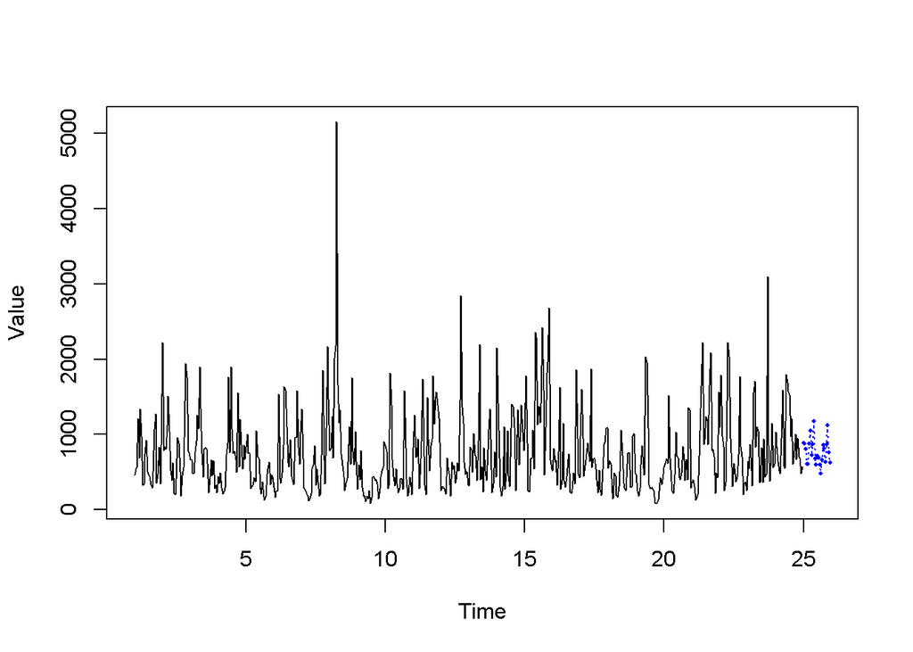

```r
# teste: previsão de vazão para 2017 e 2018
pred_munhoz <- predict(modelo_munhoz,
                       n.ahead = 12 * length(leave_out)
                       )
# Comparação dos valores observados e previstos para os dois últimos anos
plot(modelo_munhoz, pred_munhoz)
```

As previsões do PSF podem ser adicionadas aos dados originais.

```r
inds <- (nrow(train_posto_qmly) + 1):(nrow(train_posto_qmly) + (12 * length(leave_out)))

nrow(qnat_posto_mly) == max(inds)
```

```
#> [1] TRUE
```

```r
qnat_posto_mly_pred <- mutate(qnat_posto_mly,
  qnat_pred = NA,
  qnat_pred = replace(qnat_pred,
    list = inds,
    values = pred_munhoz
  )
)
tail(qnat_posto_mly_pred, 12 * length(leave_out))
```

```
#> # A tibble: 24 x 3
#>    date       qnat_obs qnat_pred
#>    <date>        <dbl>     <dbl>
#>  1 2017-01-01     971.      884.
#>  2 2017-02-01     806.      879.
#>  3 2017-03-01     454.      803.
#>  4 2017-04-01     259.      607.
#>  5 2017-05-01     586.      606.
#>  6 2017-06-01    1195.      876.
#>  7 2017-07-01     224.     1050.
#>  8 2017-08-01     318.      719.
#>  9 2017-09-01     156.      870.
#> 10 2017-10-01     687.     1176.
#> # ... with 14 more rows
```

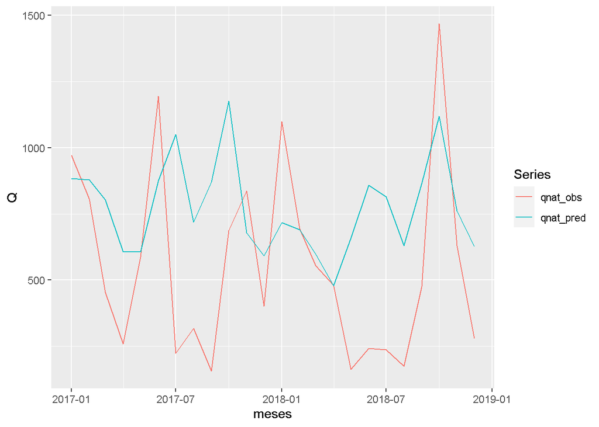

```r
df <- qnat_posto_mly_pred[inds,]
df_xts <- xts(df[,-1], order.by = as.Date(df[["date"]]))
forecast::autoplot(df_xts, facets = FALSE) +
  ylab("Q") +
  xlab("meses") +
  theme(
    strip.background = element_blank(),
    strip.text = element_blank()
  )
```

## Avaliação

A avaliação do desempenho do PSF para os últimos 24 meses considera as seguintes métricas estatísticas: erro médio absoluto (MAE), raiz quadrada do erro méio (RMSE), o RMSE normalizado pelo desvio padrão da observação (NRMSE %), O viés relativo (PBIAS %), o coeficiente de Nash-Sutcliffe, coeficiente de determinação (R<sup>2</sup>), o coeficiente de Kling-Gupta Efficiency (KGE) e VE.

```r
# seleciona índices de interesse
# ctrl+alt+c
pos_stat_inds <- c(2, 4:6, 9, 17, 19:20)

stat_eval <- hydroGOF::gof(
  sim = df_xts$qnat_pred,
  obs = df_xts$qnat_obs)[pos_stat_inds,]
stat_eval
```

```
#>     MAE    RMSE NRMSE % PBIAS %     NSE      R2     KGE      VE
#>  323.48  394.51  110.60   38.60   -0.28    0.12    0.09    0.42
```

```r
#names(stat_eval)
```

Como KGE combina correlação, viés de variabilidade e da média, ele será priorizado nesta avaliação. Valores de $KGE > -0.41$ indicam um desempenho melhor que a média das observações.

O PSF emprega o algoritmo de agrupamento `kmeans` usando o método de Hartigan–Wong. Esta técnica gera resultados mais robustos ao variar aleatoriamente os valores iniciais dos centróides dos grupos. Portanto diferentes soluções são obtidas cada vez que a função é executada. Por esta razão, foram feitas 10 iterações com diferentes sementes e a média do KGE foi usada para obter avaliar o desempenho das predições feitas pelo PSF. Somente os parâmetros `k` (número de grupos) e `w` (tamanho da janela) foram variados.

> Como comentado no livro as iterações podem ser feitas com o parâmetro `nstart`diretamente na função `stats::kmeans()` e recomendam `nstart = 25`. A função retornará o melhor resultado. Porque ele não usou isso?

```r
obs_74 <- df$qnat_obs
niter <- 10
aval74_kge <- rep(NA, niter)

for (i in 1:niter) {
  # i = 1

  # PSF
  psf_model <- psf(train_posto_qmly[["qnat_obs"]],
    k = 3:20,
    w = 1:10,
    cycle = 12
  )
  preds <- predict(psf_model,
    n.ahead = 12 * length(leave_out)
  )

  aval74_kge[i] <- KGE(
    sim = preds,
    obs = obs_74
  )
}

(KGE74_psf <- mean(aval74_kge))
```

```
#> [1] -0.008891876
```